# *ADRIS MISRA*

**Github repository:** https://github.com/GreatLearningAIML1/gl-pgp-aiml-uta-intl-aug20-adris-misra

# `Project - Thera Bank Personal Loan Campaign`

### `Data Description:`

The dataset contains data on 5000 customers. The data include customer demographic information (age, income, etc.), the customer's relationship with the bank (mortgage, securities account, etc.), and the customer response to the last personal loan campaign (Personal Loan). Among these 5000 customers, only 480 (= 9.6%) accepted the personal loan that was offered to them in the earlier campaign.

### `Domain:`

- Banking

### `Context:`

This case is about a bank (Thera Bank) whose management wants to explore ways of converting its liability customers to personal loan customers (while retaining them as depositors). A campaign that the bank ran last year for liability customers showed a healthy conversion rate of over 9% success. This has encouraged the retail marketing department to devise campaigns with better target marketing to increase the success ratio with a minimal budget.

### `Objective:`

The classification goal is to predict the likelihood of a liability customer buying personal loans.

### `Learning Outcomes:`

- Exploratory Data Analysis
- Preparing the data to train a model
- Training and making predictions using a classification model
- Model evaluation

### `Steps and tasks:`

- *Import the datasets and libraries, check datatype, statistical summary, shape, null values or incorrect imputation. (5 marks)*
- *EDA: Study the data distribution in each attribute and target variable, share your findings (20 marks)*
- *Number of unique in each column?*
- *Number of people with zero mortgage?*
- *Number of people with zero credit card spending per month?*
- *Value counts of all categorical columns.*
- *Univariate and Bivariate*
- *Get data model ready*
- *Split the data into training and test set in the ratio of 70:30 respectively (5 marks)*
- *Use the Logistic Regression model to predict whether the customer will take a personal loan or not. Print all the metrics related to evaluating the model performance (accuracy, recall, precision, f1score, and roc_auc_score). Draw a heatmap to display confusion matrix (15 marks)*
- *Find out coefficients of all the attributes and show the output in a data frame with column names? For test data show all the rows where the predicted class is not equal to the observed class. (10 marks)*
- *Give conclusion related to the Business understanding of your model? (5 marks)*

### `Attribute Information:`

- ID: Customer ID
- Age: Customer's age in completed years
- Experience: #years of professional experience
- Income: Annual income of the customer
- ZIP Code: Home Address ZIP
- Family: Family size of the customer
- CCAvg: Avg. spending on credit cards per month
- Education: Education Level.
  1. Undergrad
  2. Graduate
  3. Advanced/Professional
- Mortgage: Value of house mortgage if any.
- Personal Loan: Did this customer accept the personal loan offered in the last campaign?
- Securities Account: Does the customer have a securities account with the bank?
- CD Account: Does the customer have a certificate of deposit (CD) account with the bank?
- Online: Does the customer use internet banking facilities?
- Credit card: Does the customer use a credit card issued by the bank?

### 1. Import the datasets and libraries, check datatype, statistical summary, shape, null values or incorrect imputation. (5 marks)

```python
# Import warnings to suppress runtime warnings

import warnings
warnings.filterwarnings('ignore')
```

```python
# Import basic libraries for data and visualization

import numpy as np
import pandas as pd
import seaborn as sns
import matplotlib.pyplot as plt
sns.set(color_codes=True)
%matplotlib inline
```

```python
# Import logistic models and relevent class / functions

from sklearn.linear_model import LogisticRegression
from sklearn.model_selection import train_test_split
from sklearn.model_selection import GridSearchCV
from sklearn import metrics
from sklearn.metrics import confusion_matrix, recall_score, precision_score, f1_score, roc_auc_score,accuracy_score, roc_curve
from sklearn.metrics import precision_recall_curve
from sklearn.metrics import auc
```

```python
#  Import stats models

from scipy import stats
import statsmodels.api as sm
from statsmodels.stats.outliers_influence import variance_inflation_factor
```

```python
# read csv

cust = pd.read_csv("Bank_Personal_Loan_Modelling.csv")
```

```python
# checking sample head data

cust.head()
```

|  | ID | Age | Experience | Income | ZIP Code | Family | CCAvg | Education | Mortgage | Personal Loan | Securities Account | CD Account | Online | CreditCard |
| --- | --- | --- | --- | --- | --- | --- | --- | --- | --- | --- | --- | --- | --- | --- |
| 0 | 1 | 25 | 1 | 49 | 91107 | 4 | 1.6 | 1 | 0 | 0 | 1 | 0 | 0 | 0 |
| 1 | 2 | 45 | 19 | 34 | 90089 | 3 | 1.5 | 1 | 0 | 0 | 1 | 0 | 0 | 0 |
| 2 | 3 | 39 | 15 | 11 | 94720 | 1 | 1.0 | 1 | 0 | 0 | 0 | 0 | 0 | 0 |
| 3 | 4 | 35 | 9 | 100 | 94112 | 1 | 2.7 | 2 | 0 | 0 | 0 | 0 | 0 | 0 |
| 4 | 5 | 35 | 8 | 45 | 91330 | 4 | 1.0 | 2 | 0 | 0 | 0 | 0 | 0 | 1 |

```python
# checking sample tail data

cust.tail()
```

|  | ID | Age | Experience | Income | ZIP Code | Family | CCAvg | Education | Mortgage | Personal Loan | Securities Account | CD Account | Online | CreditCard |
| --- | --- | --- | --- | --- | --- | --- | --- | --- | --- | --- | --- | --- | --- | --- |
| 4995 | 4996 | 29 | 3 | 40 | 92697 | 1 | 1.9 | 3 | 0 | 0 | 0 | 0 | 1 | 0 |
| 4996 | 4997 | 30 | 4 | 15 | 92037 | 4 | 0.4 | 1 | 85 | 0 | 0 | 0 | 1 | 0 |
| 4997 | 4998 | 63 | 39 | 24 | 93023 | 2 | 0.3 | 3 | 0 | 0 | 0 | 0 | 0 | 0 |
| 4998 | 4999 | 65 | 40 | 49 | 90034 | 3 | 0.5 | 2 | 0 | 0 | 0 | 0 | 1 | 0 |
| 4999 | 5000 | 28 | 4 | 83 | 92612 | 3 | 0.8 | 1 | 0 | 0 | 0 | 0 | 1 | 1 |

```python
# shape of dataframe

cust.shape
```

```
(5000, 14)
```

```python
cust.info()
```

```
<class 'pandas.core.frame.DataFrame'>
RangeIndex: 5000 entries, 0 to 4999
Data columns (total 14 columns):
 #   Column              Non-Null Count  Dtype
---  ------              --------------  -----
 0   ID                  5000 non-null   int64
 1   Age                 5000 non-null   int64
 2   Experience          5000 non-null   int64
 3   Income              5000 non-null   int64
 4   ZIP Code            5000 non-null   int64
 5   Family              5000 non-null   int64
 6   CCAvg               5000 non-null   float64
 7   Education           5000 non-null   int64
 8   Mortgage            5000 non-null   int64
 9   Personal Loan       5000 non-null   int64
 10  Securities Account  5000 non-null   int64
 11  CD Account          5000 non-null   int64
 12  Online              5000 non-null   int64
 13  CreditCard          5000 non-null   int64
dtypes: float64(1), int64(13)
memory usage: 547.0 KB
```

```python
cust.describe().T
```

|  | count | mean | std | min | 25% | 50% | 75% | max |
| --- | --- | --- | --- | --- | --- | --- | --- | --- |
| ID | 5000.0 | 2500.500000 | 1443.520003 | 1.0 | 1250.75 | 2500.5 | 3750.25 | 5000.0 |
| Age | 5000.0 | 45.338400 | 11.463166 | 23.0 | 35.00 | 45.0 | 55.00 | 67.0 |
| Experience | 5000.0 | 20.104600 | 11.467954 | -3.0 | 10.00 | 20.0 | 30.00 | 43.0 |
| Income | 5000.0 | 73.774200 | 46.033729 | 8.0 | 39.00 | 64.0 | 98.00 | 224.0 |
| ZIP Code | 5000.0 | 93152.503000 | 2121.852197 | 9307.0 | 91911.00 | 93437.0 | 94608.00 | 96651.0 |
| Family | 5000.0 | 2.396400 | 1.147663 | 1.0 | 1.00 | 2.0 | 3.00 | 4.0 |
| CCAvg | 5000.0 | 1.937938 | 1.747659 | 0.0 | 0.70 | 1.5 | 2.50 | 10.0 |
| Education | 5000.0 | 1.881000 | 0.839869 | 1.0 | 1.00 | 2.0 | 3.00 | 3.0 |
| Mortgage | 5000.0 | 56.498800 | 101.713802 | 0.0 | 0.00 | 0.0 | 101.00 | 635.0 |
| Personal Loan | 5000.0 | 0.096000 | 0.294621 | 0.0 | 0.00 | 0.0 | 0.00 | 1.0 |
| Securities Account | 5000.0 | 0.104400 | 0.305809 | 0.0 | 0.00 | 0.0 | 0.00 | 1.0 |
| CD Account | 5000.0 | 0.060400 | 0.238250 | 0.0 | 0.00 | 0.0 | 0.00 | 1.0 |
| Online | 5000.0 | 0.596800 | 0.490589 | 0.0 | 0.00 | 1.0 | 1.00 | 1.0 |
| CreditCard | 5000.0 | 0.294000 | 0.455637 | 0.0 | 0.00 | 0.0 | 1.00 | 1.0 |

**Preliminary data analysis:**

- There are 5000 rows and 14 columns in the dataset
- There is no null or missing value in any of the columns
- ID column is just an unique identifier, does not have much importance in analysis. Hence can be dropped.
- Minimum experience is negative, looks like there might be some junk values or wrongly imputed values.
- Zip Code 9307 might not be right so there might be some wrong values that needs further analysis
- Also Zip code is a categorical value that needs proper encoding, if that is significant for analysis
- Education is categorical value and needs encoding </font>

### 2. EDA: Study the data distribution in each attribute and target variable, share your findings (20 marks)

#### Number of unique in each column

```python
cust.nunique()
```

```
ID                    5000
Age                     45
Experience              47
Income                 162
ZIP Code               467
Family                   4
CCAvg                  108
Education                3
Mortgage               347
Personal Loan            2
Securities Account       2
CD Account               2
Online                   2
CreditCard               2
dtype: int64
```

#### Number of people with zero mortgage

```python
len(cust[cust['Mortgage']==0].index)
```

```
3462
```

#### Number of people with zero credit card spending per month

```python
cust[cust['CCAvg']==0].count()['ID']
```

```
106
```

#### Value counts of all categorical columns

```python
cat_col=['ZIP Code', 'Education','Personal Loan','Securities Account','CD Account','Online','CreditCard']

for col in cat_col:
    print('*********',col,'***********')
    df=pd.concat([cust[col].value_counts(),cust[col].value_counts(normalize=True)*100],axis=1)
    df=df.reset_index()
    df.columns=[col,'count','frequency']
    print(df)
    print()
```

```
********* ZIP Code ***********
     ZIP Code  count  frequency
0       94720    169       3.38
1       94305    127       2.54
2       95616    116       2.32
3       90095     71       1.42
4       93106     57       1.14
..        ...    ...        ...
462     96145      1       0.02
463     94970      1       0.02
464     94598      1       0.02
465     90068      1       0.02
466     94087      1       0.02

[467 rows x 3 columns]

********* Education ***********
   Education  count  frequency
0          1   2096      41.92
1          3   1501      30.02
2          2   1403      28.06

********* Personal Loan ***********
   Personal Loan  count  frequency
0              0   4520       90.4
1              1    480        9.6

********* Securities Account ***********
   Securities Account  count  frequency
0                   0   4478      89.56
1                   1    522      10.44

********* CD Account ***********
   CD Account  count  frequency
0           0   4698      93.96
1           1    302       6.04

********* Online ***********
   Online  count  frequency
0       1   2984      59.68
1       0   2016      40.32

********* CreditCard ***********
   CreditCard  count  frequency
0           0   3530       70.6
1           1   1470       29.4
```

#### Univariate Plot

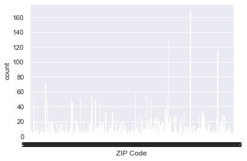

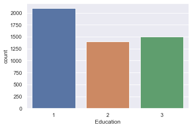

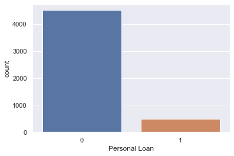

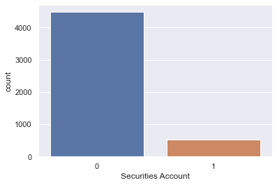

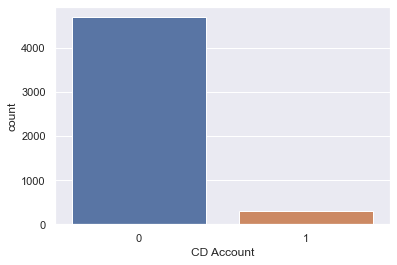

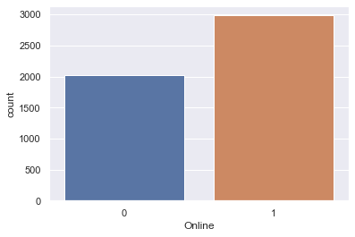

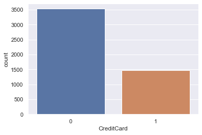

```python
# categorical columns

for col in cat_col:
    sns.countplot(cust[col])
    plt.show()
```

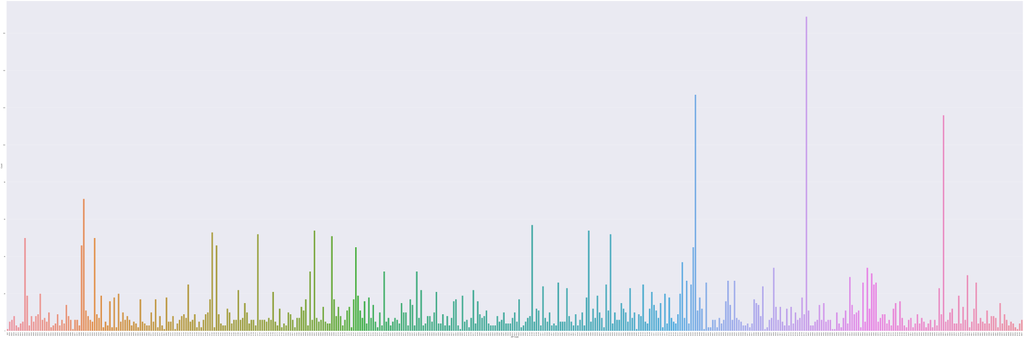

```python
#Zip code plot as it has too many values to handle

plt.figure(figsize=(150,50))
sns.countplot(x=cust['ZIP Code']);
plt.xlabel('ZIP Code', size=15);
plt.ylabel('Count', size=15);
plt.xticks(rotation=90);
```

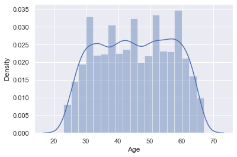

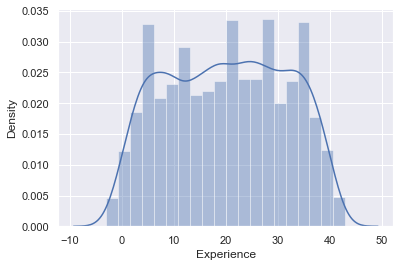

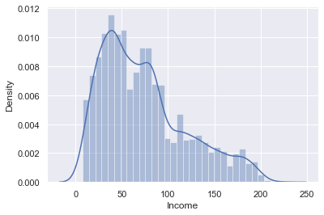

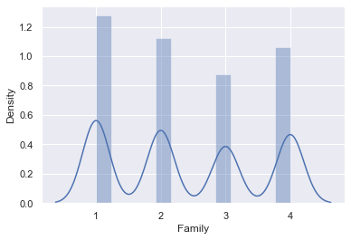

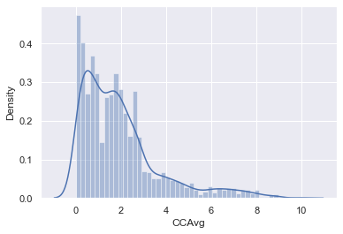

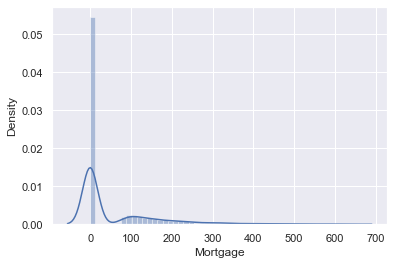

```python
# continues columns plot

cont_col=['Age','Experience','Income','Family','CCAvg','Mortgage']

for col in cont_col:
    sns.distplot(cust[col])
    plt.show()
```

**Observation:**

- Majority of the customers doesn't have mortgage
- There are some negative experiences that need to be corrected </font>

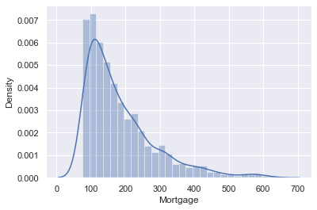

```python
# mortgage leaving 0 mortgage for better visual distribution

sns.distplot(cust[cust['Mortgage']!=0]['Mortgage'])
```

#### Bivariate Plot

```python
# dropping ID column

cust.drop(columns='ID', inplace=True)
```

```python
cust.columns
```

```
Index(['Age', 'Experience', 'Income', 'ZIP Code', 'Family', 'CCAvg',
       'Education', 'Mortgage', 'Personal Loan', 'Securities Account',
       'CD Account', 'Online', 'CreditCard'],
      dtype='object')
```

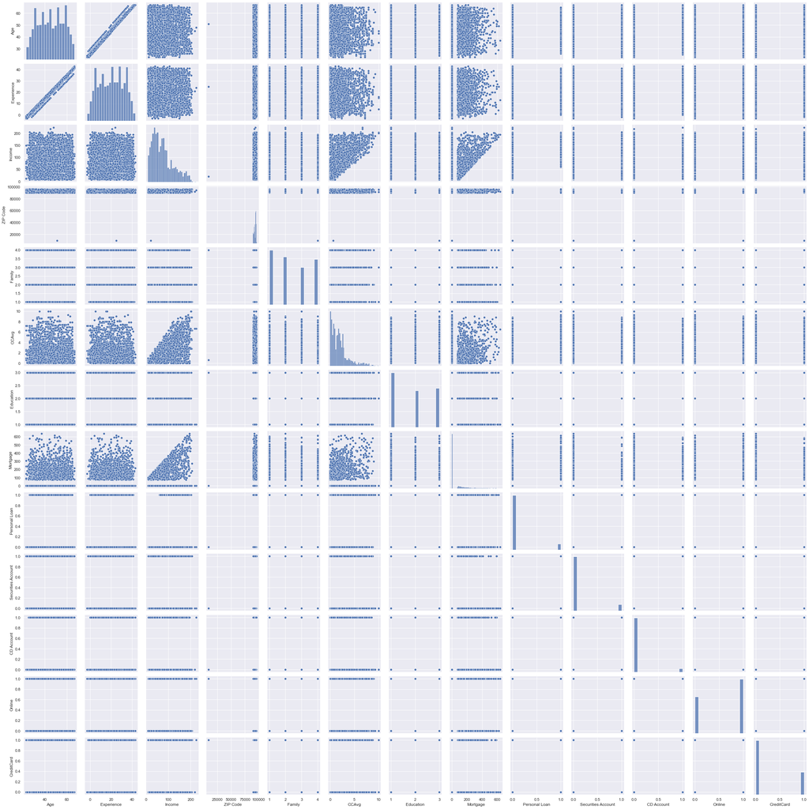

```python
sns.pairplot(cust);
```

**Observation:**

- Age and experience seems to have very strong correlation
- Also there seems to be some good correlation between Income/Mortgage and Income/CCAvg
- ZIP Code wrong value is pulling the plot towards lower value </font>

#### Few data corrections and create a copy of dataset to work upon

```python
# find wrong values of ZIP Code and drop it

loan = cust.drop(cust[cust['ZIP Code']<9999].index,axis=0)
```

```python
#find the negative experience

loan[loan['Experience']<0]
```

|  | Age | Experience | Income | ZIP Code | Family | CCAvg | Education | Mortgage | Personal Loan | Securities Account | CD Account | Online | CreditCard |
| --- | --- | --- | --- | --- | --- | --- | --- | --- | --- | --- | --- | --- | --- |
| 89 | 25 | -1 | 113 | 94303 | 4 | 2.30 | 3 | 0 | 0 | 0 | 0 | 0 | 1 |
| 226 | 24 | -1 | 39 | 94085 | 2 | 1.70 | 2 | 0 | 0 | 0 | 0 | 0 | 0 |
| 315 | 24 | -2 | 51 | 90630 | 3 | 0.30 | 3 | 0 | 0 | 0 | 0 | 1 | 0 |
| 451 | 28 | -2 | 48 | 94132 | 2 | 1.75 | 3 | 89 | 0 | 0 | 0 | 1 | 0 |
| 524 | 24 | -1 | 75 | 93014 | 4 | 0.20 | 1 | 0 | 0 | 0 | 0 | 1 | 0 |
| 536 | 25 | -1 | 43 | 92173 | 3 | 2.40 | 2 | 176 | 0 | 0 | 0 | 1 | 0 |
| 540 | 25 | -1 | 109 | 94010 | 4 | 2.30 | 3 | 314 | 0 | 0 | 0 | 1 | 0 |
| 576 | 25 | -1 | 48 | 92870 | 3 | 0.30 | 3 | 0 | 0 | 0 | 0 | 0 | 1 |
| 583 | 24 | -1 | 38 | 95045 | 2 | 1.70 | 2 | 0 | 0 | 0 | 0 | 1 | 0 |
| 597 | 24 | -2 | 125 | 92835 | 2 | 7.20 | 1 | 0 | 0 | 1 | 0 | 0 | 1 |
| 649 | 25 | -1 | 82 | 92677 | 4 | 2.10 | 3 | 0 | 0 | 0 | 0 | 1 | 0 |
| 670 | 23 | -1 | 61 | 92374 | 4 | 2.60 | 1 | 239 | 0 | 0 | 0 | 1 | 0 |
| 686 | 24 | -1 | 38 | 92612 | 4 | 0.60 | 2 | 0 | 0 | 0 | 0 | 1 | 0 |
| 793 | 24 | -2 | 150 | 94720 | 2 | 2.00 | 1 | 0 | 0 | 0 | 0 | 1 | 0 |
| 889 | 24 | -2 | 82 | 91103 | 2 | 1.60 | 3 | 0 | 0 | 0 | 0 | 1 | 1 |
| 909 | 23 | -1 | 149 | 91709 | 1 | 6.33 | 1 | 305 | 0 | 0 | 0 | 0 | 1 |
| 1173 | 24 | -1 | 35 | 94305 | 2 | 1.70 | 2 | 0 | 0 | 0 | 0 | 0 | 0 |
| 1428 | 25 | -1 | 21 | 94583 | 4 | 0.40 | 1 | 90 | 0 | 0 | 0 | 1 | 0 |
| 1522 | 25 | -1 | 101 | 94720 | 4 | 2.30 | 3 | 256 | 0 | 0 | 0 | 0 | 1 |
| 1905 | 25 | -1 | 112 | 92507 | 2 | 2.00 | 1 | 241 | 0 | 0 | 0 | 1 | 0 |
| 2102 | 25 | -1 | 81 | 92647 | 2 | 1.60 | 3 | 0 | 0 | 0 | 0 | 1 | 1 |
| 2430 | 23 | -1 | 73 | 92120 | 4 | 2.60 | 1 | 0 | 0 | 0 | 0 | 1 | 0 |
| 2466 | 24 | -2 | 80 | 94105 | 2 | 1.60 | 3 | 0 | 0 | 0 | 0 | 1 | 0 |
| 2545 | 25 | -1 | 39 | 94720 | 3 | 2.40 | 2 | 0 | 0 | 0 | 0 | 1 | 0 |
| 2618 | 23 | -3 | 55 | 92704 | 3 | 2.40 | 2 | 145 | 0 | 0 | 0 | 1 | 0 |
| 2717 | 23 | -2 | 45 | 95422 | 4 | 0.60 | 2 | 0 | 0 | 0 | 0 | 1 | 1 |
| 2848 | 24 | -1 | 78 | 94720 | 2 | 1.80 | 2 | 0 | 0 | 0 | 0 | 0 | 0 |
| 2876 | 24 | -2 | 80 | 91107 | 2 | 1.60 | 3 | 238 | 0 | 0 | 0 | 0 | 0 |
| 2962 | 23 | -2 | 81 | 91711 | 2 | 1.80 | 2 | 0 | 0 | 0 | 0 | 0 | 0 |
| 2980 | 25 | -1 | 53 | 94305 | 3 | 2.40 | 2 | 0 | 0 | 0 | 0 | 0 | 0 |
| 3076 | 29 | -1 | 62 | 92672 | 2 | 1.75 | 3 | 0 | 0 | 0 | 0 | 0 | 1 |
| 3130 | 23 | -2 | 82 | 92152 | 2 | 1.80 | 2 | 0 | 0 | 1 | 0 | 0 | 1 |
| 3157 | 23 | -1 | 13 | 94720 | 4 | 1.00 | 1 | 84 | 0 | 0 | 0 | 1 | 0 |
| 3279 | 26 | -1 | 44 | 94901 | 1 | 2.00 | 2 | 0 | 0 | 0 | 0 | 0 | 0 |
| 3284 | 25 | -1 | 101 | 95819 | 4 | 2.10 | 3 | 0 | 0 | 0 | 0 | 0 | 1 |
| 3292 | 25 | -1 | 13 | 95616 | 4 | 0.40 | 1 | 0 | 0 | 1 | 0 | 0 | 0 |
| 3394 | 25 | -1 | 113 | 90089 | 4 | 2.10 | 3 | 0 | 0 | 0 | 0 | 1 | 0 |
| 3425 | 23 | -1 | 12 | 91605 | 4 | 1.00 | 1 | 90 | 0 | 0 | 0 | 1 | 0 |
| 3626 | 24 | -3 | 28 | 90089 | 4 | 1.00 | 3 | 0 | 0 | 0 | 0 | 0 | 0 |
| 3796 | 24 | -2 | 50 | 94920 | 3 | 2.40 | 2 | 0 | 0 | 1 | 0 | 0 | 0 |
| 3824 | 23 | -1 | 12 | 95064 | 4 | 1.00 | 1 | 0 | 0 | 1 | 0 | 0 | 1 |
| 3887 | 24 | -2 | 118 | 92634 | 2 | 7.20 | 1 | 0 | 0 | 1 | 0 | 1 | 0 |
| 3946 | 25 | -1 | 40 | 93117 | 3 | 2.40 | 2 | 0 | 0 | 0 | 0 | 1 | 0 |
| 4015 | 25 | -1 | 139 | 93106 | 2 | 2.00 | 1 | 0 | 0 | 0 | 0 | 0 | 1 |
| 4088 | 29 | -1 | 71 | 94801 | 2 | 1.75 | 3 | 0 | 0 | 0 | 0 | 0 | 0 |
| 4116 | 24 | -2 | 135 | 90065 | 2 | 7.20 | 1 | 0 | 0 | 0 | 0 | 1 | 0 |
| 4285 | 23 | -3 | 149 | 93555 | 2 | 7.20 | 1 | 0 | 0 | 0 | 0 | 1 | 0 |
| 4411 | 23 | -2 | 75 | 90291 | 2 | 1.80 | 2 | 0 | 0 | 0 | 0 | 1 | 1 |
| 4481 | 25 | -2 | 35 | 95045 | 4 | 1.00 | 3 | 0 | 0 | 0 | 0 | 1 | 0 |
| 4514 | 24 | -3 | 41 | 91768 | 4 | 1.00 | 3 | 0 | 0 | 0 | 0 | 1 | 0 |
| 4582 | 25 | -1 | 69 | 92691 | 3 | 0.30 | 3 | 0 | 0 | 0 | 0 | 1 | 0 |
| 4957 | 29 | -1 | 50 | 95842 | 2 | 1.75 | 3 | 0 | 0 | 0 | 0 | 0 | 1 |

**Observation:**

- For all the negative experinces age group in young generation and negative values are also low
- So it looks like negative is just a typo and the experence can the the absolute value. </font>

```python
# replacing with absolute value based on above observation

loan['Experience'] = loan['Experience'].abs()
```

```python
#find the negative experience if any

loan[loan['Experience']<0]
```

|  | Age | Experience | Income | ZIP Code | Family | CCAvg | Education | Mortgage | Personal Loan | Securities Account | CD Account | Online | CreditCard |
| --- | --- | --- | --- | --- | --- | --- | --- | --- | --- | --- | --- | --- | --- |

```python
# checking data if looks good

loan
```

|  | Age | Experience | Income | ZIP Code | Family | CCAvg | Education | Mortgage | Personal Loan | Securities Account | CD Account | Online | CreditCard |
| --- | --- | --- | --- | --- | --- | --- | --- | --- | --- | --- | --- | --- | --- |
| 0 | 25 | 1 | 49 | 91107 | 4 | 1.6 | 1 | 0 | 0 | 1 | 0 | 0 | 0 |
| 1 | 45 | 19 | 34 | 90089 | 3 | 1.5 | 1 | 0 | 0 | 1 | 0 | 0 | 0 |
| 2 | 39 | 15 | 11 | 94720 | 1 | 1.0 | 1 | 0 | 0 | 0 | 0 | 0 | 0 |
| 3 | 35 | 9 | 100 | 94112 | 1 | 2.7 | 2 | 0 | 0 | 0 | 0 | 0 | 0 |
| 4 | 35 | 8 | 45 | 91330 | 4 | 1.0 | 2 | 0 | 0 | 0 | 0 | 0 | 1 |
| ... | ... | ... | ... | ... | ... | ... | ... | ... | ... | ... | ... | ... | ... |
| 4995 | 29 | 3 | 40 | 92697 | 1 | 1.9 | 3 | 0 | 0 | 0 | 0 | 1 | 0 |
| 4996 | 30 | 4 | 15 | 92037 | 4 | 0.4 | 1 | 85 | 0 | 0 | 0 | 1 | 0 |
| 4997 | 63 | 39 | 24 | 93023 | 2 | 0.3 | 3 | 0 | 0 | 0 | 0 | 0 | 0 |
| 4998 | 65 | 40 | 49 | 90034 | 3 | 0.5 | 2 | 0 | 0 | 0 | 0 | 1 | 0 |
| 4999 | 28 | 4 | 83 | 92612 | 3 | 0.8 | 1 | 0 | 0 | 0 | 0 | 1 | 1 |

4999 rows × 13 columns

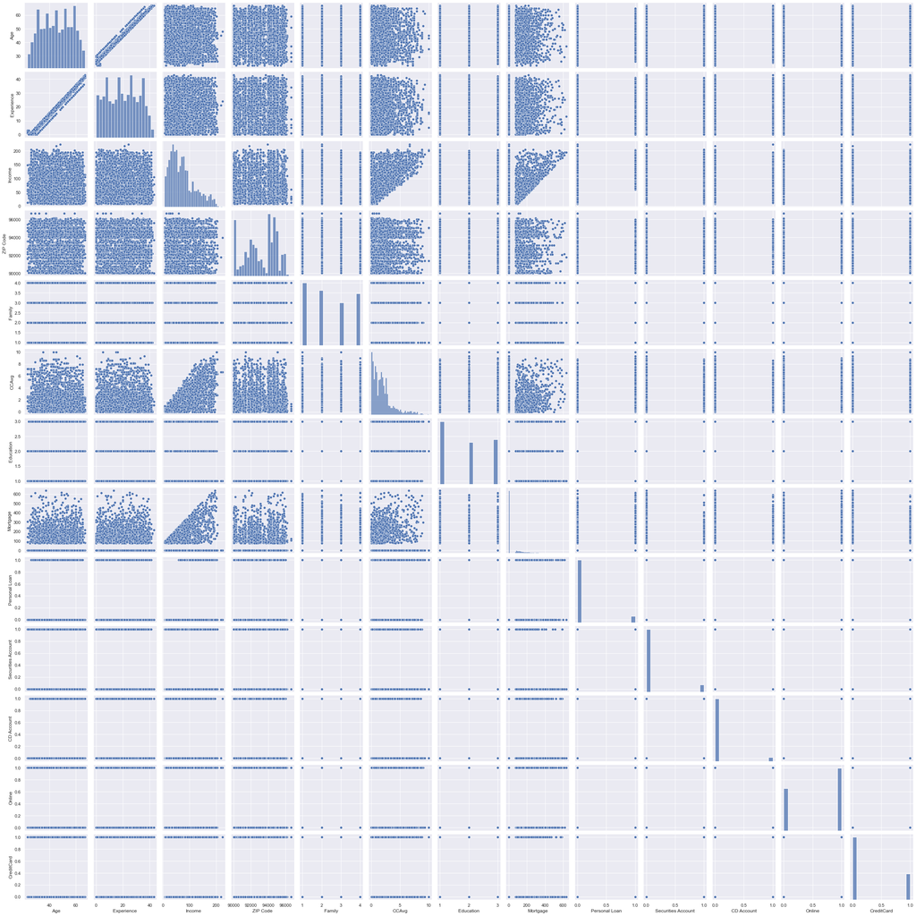

```python
# checking pairplot one more time after data correction

sns.pairplot(loan);
```

```python
# checking unique count of ZIP for for personal loan status

loan.groupby('Personal Loan')['ZIP Code'].nunique()
```

```
Personal Loan
0    466
1    238
Name: ZIP Code, dtype: int64
```

**Observation:**

- There are too many values in each loan status for encoding
- It might be wise to frop ZIP Code or see the distribution on 1st two charecters of ZIP Code that might give us some Zonal influence factor </font>

```python
# convert loan['ZIP Code'] to string

loan['ZIP Code'] = loan['ZIP Code'].astype(str)
```

```python
# check datatype

loan.info()
```

```
<class 'pandas.core.frame.DataFrame'>
Int64Index: 4999 entries, 0 to 4999
Data columns (total 13 columns):
 #   Column              Non-Null Count  Dtype
---  ------              --------------  -----
 0   Age                 4999 non-null   int64
 1   Experience          4999 non-null   int64
 2   Income              4999 non-null   int64
 3   ZIP Code            4999 non-null   object
 4   Family              4999 non-null   int64
 5   CCAvg               4999 non-null   float64
 6   Education           4999 non-null   int64
 7   Mortgage            4999 non-null   int64
 8   Personal Loan       4999 non-null   int64
 9   Securities Account  4999 non-null   int64
 10  CD Account          4999 non-null   int64
 11  Online              4999 non-null   int64
 12  CreditCard          4999 non-null   int64
dtypes: float64(1), int64(11), object(1)
memory usage: 546.8+ KB
```

```python
# substring first two character of ZIP as Zone

loan['zone'] = loan['ZIP Code'].str[:2]
```

```python
# checking data

loan
```

|  | Age | Experience | Income | ZIP Code | Family | CCAvg | Education | Mortgage | Personal Loan | Securities Account | CD Account | Online | CreditCard | zone |
| --- | --- | --- | --- | --- | --- | --- | --- | --- | --- | --- | --- | --- | --- | --- |
| 0 | 25 | 1 | 49 | 91107 | 4 | 1.6 | 1 | 0 | 0 | 1 | 0 | 0 | 0 | 91 |
| 1 | 45 | 19 | 34 | 90089 | 3 | 1.5 | 1 | 0 | 0 | 1 | 0 | 0 | 0 | 90 |
| 2 | 39 | 15 | 11 | 94720 | 1 | 1.0 | 1 | 0 | 0 | 0 | 0 | 0 | 0 | 94 |
| 3 | 35 | 9 | 100 | 94112 | 1 | 2.7 | 2 | 0 | 0 | 0 | 0 | 0 | 0 | 94 |
| 4 | 35 | 8 | 45 | 91330 | 4 | 1.0 | 2 | 0 | 0 | 0 | 0 | 0 | 1 | 91 |
| ... | ... | ... | ... | ... | ... | ... | ... | ... | ... | ... | ... | ... | ... | ... |
| 4995 | 29 | 3 | 40 | 92697 | 1 | 1.9 | 3 | 0 | 0 | 0 | 0 | 1 | 0 | 92 |
| 4996 | 30 | 4 | 15 | 92037 | 4 | 0.4 | 1 | 85 | 0 | 0 | 0 | 1 | 0 | 92 |
| 4997 | 63 | 39 | 24 | 93023 | 2 | 0.3 | 3 | 0 | 0 | 0 | 0 | 0 | 0 | 93 |
| 4998 | 65 | 40 | 49 | 90034 | 3 | 0.5 | 2 | 0 | 0 | 0 | 0 | 1 | 0 | 90 |
| 4999 | 28 | 4 | 83 | 92612 | 3 | 0.8 | 1 | 0 | 0 | 0 | 0 | 1 | 1 | 92 |

4999 rows × 14 columns

```python
# checking unique count of zone for for personal loan status

loan.groupby('Personal Loan')['zone'].nunique()
```

```
Personal Loan
0    7
1    7
Name: zone, dtype: int64
```

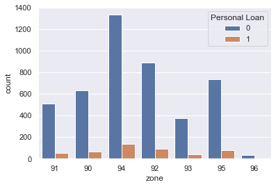

```python
sns.countplot(x=loan['zone'],hue=loan['Personal Loan']);
```

```python
#dropping ZIP Code

loan.drop('ZIP Code',axis=1, inplace=True)
```

```python
# check data types

loan.info()
```

```
<class 'pandas.core.frame.DataFrame'>
Int64Index: 4999 entries, 0 to 4999
Data columns (total 13 columns):
 #   Column              Non-Null Count  Dtype
---  ------              --------------  -----
 0   Age                 4999 non-null   int64
 1   Experience          4999 non-null   int64
 2   Income              4999 non-null   int64
 3   Family              4999 non-null   int64
 4   CCAvg               4999 non-null   float64
 5   Education           4999 non-null   int64
 6   Mortgage            4999 non-null   int64
 7   Personal Loan       4999 non-null   int64
 8   Securities Account  4999 non-null   int64
 9   CD Account          4999 non-null   int64
 10  Online              4999 non-null   int64
 11  CreditCard          4999 non-null   int64
 12  zone                4999 non-null   object
dtypes: float64(1), int64(11), object(1)
memory usage: 706.8+ KB
```

```python
# change education to category

loan['Education'] = loan['Education'].astype(str)
```

```python
# verify datatypes

loan.info()
```

```
<class 'pandas.core.frame.DataFrame'>
Int64Index: 4999 entries, 0 to 4999
Data columns (total 13 columns):
 #   Column              Non-Null Count  Dtype
---  ------              --------------  -----
 0   Age                 4999 non-null   int64
 1   Experience          4999 non-null   int64
 2   Income              4999 non-null   int64
 3   Family              4999 non-null   int64
 4   CCAvg               4999 non-null   float64
 5   Education           4999 non-null   object
 6   Mortgage            4999 non-null   int64
 7   Personal Loan       4999 non-null   int64
 8   Securities Account  4999 non-null   int64
 9   CD Account          4999 non-null   int64
 10  Online              4999 non-null   int64
 11  CreditCard          4999 non-null   int64
 12  zone                4999 non-null   object
dtypes: float64(1), int64(10), object(2)
memory usage: 706.8+ KB
```

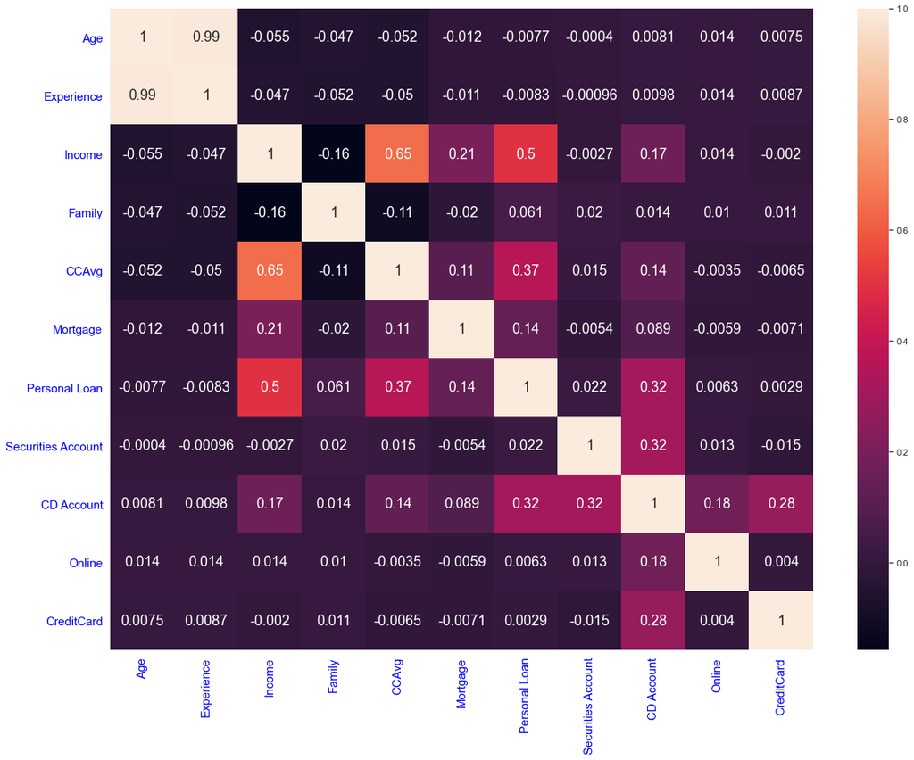

```python
# correlation matrix

plt.figure(figsize=(20,15))
sns.heatmap(loan.corr(), annot=True, annot_kws={"size":18});
plt.xticks(rotation=90, size=15, color='blue');
plt.yticks(size=15, color='blue');
```

**Observation:**

- Age and experience are strongly correlated
- Also there seems to be some good correlation between Income/Mortgage and Income/CCAvg
- As very strong correlation opposes the regression assumption that independent variables are not highly correlated we might consider dropping Experience </font>

#### Get data model ready

```python
loan.columns
```

```
Index(['Age', 'Experience', 'Income', 'Family', 'CCAvg', 'Education',
       'Mortgage', 'Personal Loan', 'Securities Account', 'CD Account',
       'Online', 'CreditCard', 'zone'],
      dtype='object')
```

```python
# Defining independent and dependent variable

X = loan.drop(['Personal Loan', 'Experience'],axis=1)
y = loan['Personal Loan'].astype('category')
```

```python
# convert categorical variables to dummy variables

X = pd.get_dummies(X, drop_first = True)
```

```python
X.columns
```

```
Index(['Age', 'Income', 'Family', 'CCAvg', 'Mortgage', 'Securities Account',
       'CD Account', 'Online', 'CreditCard', 'Education_2', 'Education_3',
       'zone_91', 'zone_92', 'zone_93', 'zone_94', 'zone_95', 'zone_96'],
      dtype='object')
```

### 3. Split the data into training and test set in the ratio of 70:30 respectively (5 marks)

```python
X_train, X_test, y_train, y_test = train_test_split( X, y, test_size=0.30, random_state=1)
```

```python
# checking if distribution between train and test are similar to the original sample

print('y:\n', y.value_counts(normalize=True)*100)
print('\n\ny_train:\n', y_train.value_counts(normalize=True)*100)
print('\n\ny_test:\n', y_test.value_counts(normalize=True)*100)
```

```
y:
 0    90.39808
1     9.60192
Name: Personal Loan, dtype: float64


y_train:
 0    90.511575
1     9.488425
Name: Personal Loan, dtype: float64


y_test:
 0    90.133333
1     9.866667
Name: Personal Loan, dtype: float64
```

**Observation:**

- Distribution looks good </font>

### 4. Use the Logistic Regression model to predict whether the customer will take a personal loan or not. Print all the metrics related to evaluating the model performance (accuracy, recall, precision, f1score, and roc_auc_score). Draw a heatmap to display confusion matrix (15 marks)

```python
 # creating Logistic Regression model and fit the model on train data

logreg = LogisticRegression(random_state=1)

logreg.fit(X_train, y_train)
```

```
LogisticRegression(C=1.0, class_weight=None, dual=False, fit_intercept=True,
          intercept_scaling=1, max_iter=100, multi_class='warn',
          n_jobs=None, penalty='l2', random_state=1, solver='warn',
          tol=0.0001, verbose=0, warm_start=False)
```

```python
# Predicting the target variable on test data

y_predict = logreg.predict(X_test)
```

```python
# View the predicted and Observed class in a datafreame

Z = X_test.copy()
Z['Observed Personal Loan'] = y_test
Z['Predicted Personal Loan'] = y_predict

Z
```

|  | Age | Income | Family | CCAvg | Mortgage | Securities Account | CD Account | Online | CreditCard | Education_2 | Education_3 | zone_91 | zone_92 | zone_93 | zone_94 | zone_95 | zone_96 | Observed Personal Loan | Predicted Personal Loan |
| --- | --- | --- | --- | --- | --- | --- | --- | --- | --- | --- | --- | --- | --- | --- | --- | --- | --- | --- | --- |
| 4996 | 30 | 15 | 4 | 0.4 | 85 | 0 | 0 | 1 | 0 | 0 | 0 | 0 | 1 | 0 | 0 | 0 | 0 | 0 | 0 |
| 4419 | 42 | 85 | 1 | 3.7 | 272 | 0 | 0 | 0 | 0 | 0 | 1 | 0 | 0 | 1 | 0 | 0 | 0 | 0 | 0 |
| 3000 | 40 | 164 | 1 | 4.3 | 0 | 0 | 0 | 0 | 0 | 1 | 0 | 0 | 0 | 0 | 1 | 0 | 0 | 1 | 1 |
| 4715 | 65 | 35 | 1 | 0.5 | 150 | 0 | 0 | 1 | 0 | 0 | 1 | 0 | 1 | 0 | 0 | 0 | 0 | 0 | 0 |
| 2264 | 35 | 9 | 4 | 0.7 | 0 | 0 | 0 | 1 | 0 | 1 | 0 | 0 | 0 | 1 | 0 | 0 | 0 | 0 | 0 |
| ... | ... | ... | ... | ... | ... | ... | ... | ... | ... | ... | ... | ... | ... | ... | ... | ... | ... | ... | ... |
| 4140 | 63 | 32 | 1 | 1.5 | 0 | 0 | 0 | 0 | 0 | 1 | 0 | 0 | 0 | 0 | 1 | 0 | 0 | 0 | 0 |
| 3054 | 45 | 134 | 4 | 5.5 | 0 | 0 | 1 | 1 | 1 | 1 | 0 | 0 | 1 | 0 | 0 | 0 | 0 | 1 | 1 |
| 2074 | 52 | 81 | 1 | 1.3 | 293 | 0 | 0 | 0 | 1 | 0 | 1 | 1 | 0 | 0 | 0 | 0 | 0 | 0 | 0 |
| 1362 | 31 | 85 | 3 | 1.6 | 157 | 0 | 0 | 1 | 1 | 0 | 0 | 0 | 1 | 0 | 0 | 0 | 0 | 0 | 0 |
| 1459 | 47 | 38 | 3 | 2.5 | 0 | 0 | 0 | 0 | 0 | 1 | 0 | 0 | 1 | 0 | 0 | 0 | 0 | 0 | 0 |

1500 rows × 19 columns

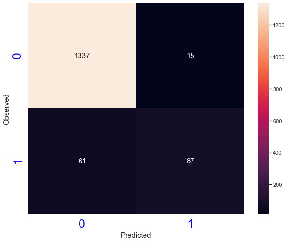

```python
# confusion matrix

cm= confusion_matrix(y_test,y_predict)
plt.figure(figsize=(10,8))
sns.heatmap(cm, annot=True, fmt='.0f', annot_kws={"size":15})
plt.ylabel('Observed', size=15)
plt.xlabel('Predicted', size=15);
plt.xticks(size=25, color='blue');
plt.yticks(size=25, color='blue');
```

```python
# Trainiing accuracy

logreg.score(X_train,y_train)
```

```
0.9554158330951701
```

```python
# Test accuracy

logreg.score(X_test,y_test)
```

```
0.9493333333333334
```

```python
# recall

recall_score(y_test,y_predict, pos_label=1)
```

```
0.5878378378378378
```

```python
# precision

precision_score(y_test,y_predict, pos_label=1)
```

```
0.8529411764705882
```

```python
# f1 Score

f1_score(y_test,y_predict, pos_label=1)
```

```
0.696
```

```python
# ROC_AUC score

roc_auc_score(y_test,y_predict)
```

```
0.7883715816408123
```

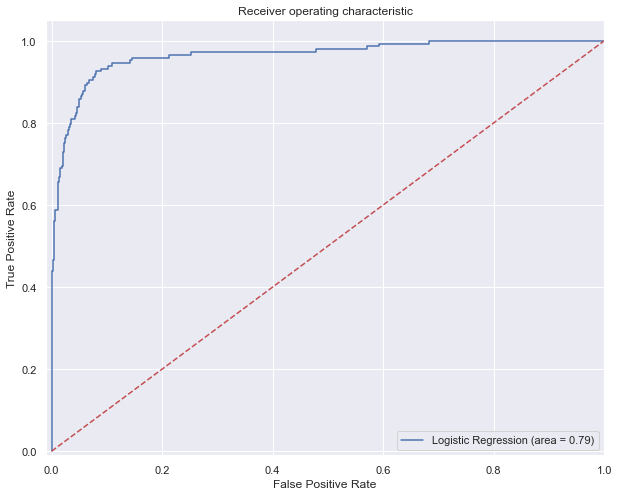

```python
#AUC ROC curve

logit_roc_auc = roc_auc_score(y_test, logreg.predict(X_test))
fpr, tpr, thresholds = roc_curve(y_test, logreg.predict_proba(X_test)[:,1],pos_label=1)
plt.figure(figsize=(10,8))
plt.plot(fpr, tpr, label='Logistic Regression (area = %0.2f)' % logit_roc_auc)
plt.plot([0, 1], [0, 1],'r--')
plt.xlim([-0.01, 1.0])
plt.ylim([-0.01, 1.05])
plt.xlabel('False Positive Rate')
plt.ylabel('True Positive Rate')
plt.title('Receiver operating characteristic')
plt.legend(loc="lower right")
plt.show()
```

```python
# get the best threshold
J = tpr - fpr
ix = np.argmax(J)
best_thresh = thresholds[ix]
print('Best Threshold=%f' % (best_thresh))
```

```
Best Threshold=0.142088
```

```
Logistic: f1=0.696 auc=0.852
```

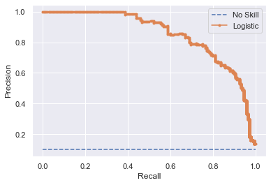

```python
# Precision Recall Curve

# calculate precision and recall for each threshold
lr_precision, lr_recall, threshold = precision_recall_curve(y_test, logreg.predict_proba(X_test)[:,1], pos_label=1)
# calculate scores
lr_f1, lr_auc = f1_score(y_test,y_predict, pos_label=1), auc(lr_recall, lr_precision)
# summarize scores
print('Logistic: f1=%.3f auc=%.3f' % (lr_f1, lr_auc))
# plot the precision-recall curves
no_skill = len(y_test[y_test==1]) / len(y_test)
plt.plot([0, 1], [no_skill, no_skill], linestyle='--', label='No Skill')
plt.plot(lr_recall, lr_precision, marker='.', label='Logistic')
# axis labels
plt.xlabel('Recall')
plt.ylabel('Precision')
# show the legend
plt.legend()
# show the plot
plt.show()
```

```python
# convert to f score
fscore = (2 * lr_precision * lr_recall) / (lr_precision + lr_recall)
# locate the index of the largest f score
ix = np.argmax(fscore)
print('Best Threshold=%f, F-Score=%.3f' % (threshold[ix], fscore[ix]))
```

```
Best Threshold=0.293276, F-Score=0.771
```

### 5. Find out coefficients of all the attributes and show the output in a data frame with column names? For test data show all the rows where the predicted class is not equal to the observed class. (10 marks)

```python
coeff = pd.DataFrame()
coeff['field'] = X_train.columns
coeff['coeff_value'] = np.round(logreg.coef_[0],4)
coeff= coeff.append({'coeff_value': np.round(logreg.intercept_[0],4), 'field': 'Intercept'}, ignore_index = True)
coeff['impact'] = coeff['coeff_value'].apply(lambda x: '+' if x>=0 else '-')
coeff['coeff_value'] = coeff['coeff_value'].abs()
coeff.sort_values(by='coeff_value', ascending=False)
```

|  | field | coeff_value | impact |
| --- | --- | --- | --- |
| 17 | Intercept | 8.6984 | - |
| 6 | CD Account | 2.7656 | + |
| 10 | Education_3 | 2.7263 | + |
| 9 | Education_2 | 2.7022 | + |
| 8 | CreditCard | 0.8048 | - |
| 11 | zone_91 | 0.7154 | - |
| 5 | Securities Account | 0.6196 | - |
| 7 | Online | 0.5207 | - |
| 2 | Family | 0.3992 | + |
| 15 | zone_95 | 0.3538 | - |
| 14 | zone_94 | 0.3426 | - |
| 16 | zone_96 | 0.3376 | - |
| 13 | zone_93 | 0.2918 | - |
| 12 | zone_92 | 0.2266 | - |
| 3 | CCAvg | 0.1031 | + |
| 1 | Income | 0.0456 | + |
| 0 | Age | 0.0161 | - |
| 4 | Mortgage | 0.0004 | + |

```python
# test data dataframe Z derived above under QS 4
# showing result where Predicted class is not equal to observed class

Z[Z['Predicted Personal Loan'] != Z['Observed Personal Loan']]
```

|  | Age | Income | Family | CCAvg | Mortgage | Securities Account | CD Account | Online | CreditCard | Education_2 | Education_3 | zone_91 | zone_92 | zone_93 | zone_94 | zone_95 | zone_96 | Observed Personal Loan | Predicted Personal Loan |
| --- | --- | --- | --- | --- | --- | --- | --- | --- | --- | --- | --- | --- | --- | --- | --- | --- | --- | --- | --- |
| 4156 | 37 | 193 | 1 | 8.6 | 0 | 0 | 0 | 0 | 0 | 0 | 0 | 0 | 1 | 0 | 0 | 0 | 0 | 0 | 1 |
| 3288 | 56 | 140 | 4 | 0.5 | 292 | 0 | 0 | 0 | 0 | 0 | 0 | 0 | 0 | 0 | 1 | 0 | 0 | 1 | 0 |
| 1882 | 56 | 125 | 3 | 0.6 | 342 | 0 | 1 | 1 | 1 | 0 | 0 | 1 | 0 | 0 | 0 | 0 | 0 | 1 | 0 |
| 3742 | 32 | 181 | 1 | 6.0 | 0 | 0 | 1 | 1 | 1 | 0 | 0 | 0 | 0 | 0 | 1 | 0 | 0 | 0 | 1 |
| 349 | 26 | 60 | 2 | 3.0 | 132 | 0 | 0 | 0 | 0 | 0 | 0 | 0 | 0 | 1 | 0 | 0 | 0 | 1 | 0 |
| ... | ... | ... | ... | ... | ... | ... | ... | ... | ... | ... | ... | ... | ... | ... | ... | ... | ... | ... | ... |
| 3543 | 37 | 194 | 2 | 0.0 | 0 | 0 | 0 | 0 | 0 | 0 | 0 | 0 | 0 | 0 | 1 | 0 | 0 | 0 | 1 |
| 400 | 36 | 179 | 3 | 6.6 | 0 | 0 | 0 | 1 | 0 | 0 | 0 | 0 | 0 | 0 | 1 | 0 | 0 | 1 | 0 |
| 1129 | 30 | 73 | 3 | 3.3 | 0 | 0 | 1 | 1 | 1 | 0 | 0 | 0 | 0 | 0 | 1 | 0 | 0 | 1 | 0 |
| 4593 | 54 | 133 | 1 | 5.0 | 0 | 0 | 0 | 0 | 1 | 1 | 0 | 0 | 0 | 0 | 0 | 1 | 0 | 1 | 0 |
| 3605 | 61 | 130 | 2 | 2.6 | 0 | 0 | 0 | 0 | 0 | 0 | 1 | 0 | 1 | 0 | 0 | 0 | 0 | 1 | 0 |

76 rows × 19 columns

### 6. Give conclusion related to the Business understanding of your model? (5 marks)

**Looking into confusion matrix:**

- TP: 87
- TN: 1337
- FP: 15
- FN: 61

so here FN looks high when comparing to TP

For this reason recall score at .58 is not so good.

Whereas Precision, f1 score and ROC AUC score looks good. so overall it looks like model is performing good. adjusting some thresold might give better result on recall.

Looking into coefficient values Mortgage, Age, Income and CCAvg doesn't seem to have much impact on the model. Also as Mortgage, CCAvg and Income has some multicollinearity relation, dropping one or two of those might improve the model performance. But that needs further analysis to decide.

As bank wants to convert more people to personal loan TP should be high and FN should be low, so **recall** is important metric here.

After tuning the model further and adjusting to proper threshold we can deploy the model for prediction.

## Additional analysis

#### Changing threshold based on probability

```python
# Adjusting threshold

threshold = 0.142088
y_predict_th1 = np.where(logreg.predict_proba(X_test)[:,1]>threshold,1,0)
```

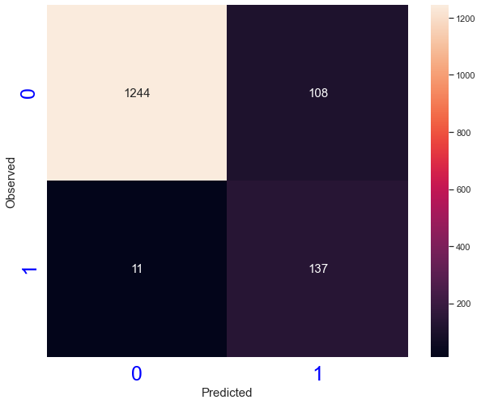

```python
# confusion matrix

cm_th1= confusion_matrix(y_test,y_predict_th1)
plt.figure(figsize=(10,8))
sns.heatmap(cm_th1, annot=True, fmt='.0f', annot_kws={"size":15})
plt.ylabel('Observed', size=15)
plt.xlabel('Predicted', size=15);
plt.xticks(size=25, color='blue');
plt.yticks(size=25, color='blue');
```

```python
print("Recall:",recall_score(y_test,y_predict_th1))
print()
print("Precision:",precision_score(y_test,y_predict_th1))
print()
print("F1 Score:",f1_score(y_test,y_predict_th1))
print()
print("Roc Auc Score:",roc_auc_score(y_test,y_predict_th1))
```

```
Recall: 0.9256756756756757

Precision: 0.5591836734693878

F1 Score: 0.6972010178117048

Roc Auc Score: 0.9228970094354709
```

**Observation:**

- Though using this threshold recall improves significantly but Precision falls significantly.
- But considering bank's objective to identify potential loan customer threshold value 0.142088 might work better even through there is larger FP value </font>

```python
# Adjusting threshold

threshold = 0.293276
y_predict_th2 = np.where(logreg.predict_proba(X_test)[:,1]>threshold,1,0)
```

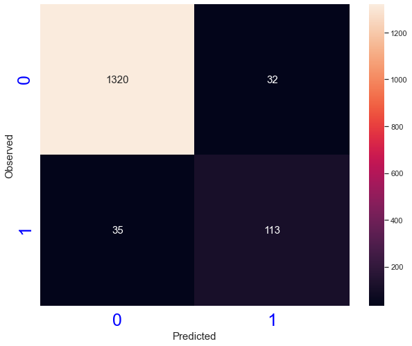

```python
# confusion matrix

cm_th2= confusion_matrix(y_test,y_predict_th2)
plt.figure(figsize=(10,8))
sns.heatmap(cm_th2, annot=True, fmt='.0f', annot_kws={"size":15})
plt.ylabel('Observed', size=15)
plt.xlabel('Predicted', size=15);
plt.xticks(size=25, color='blue');
plt.yticks(size=25, color='blue');
```

```python
print("Recall:",recall_score(y_test,y_predict_th2))
print()
print("Precision:",precision_score(y_test,y_predict_th2))
print()
print("F1 Score:",f1_score(y_test,y_predict_th2))
print()
print("Roc Auc Score:",roc_auc_score(y_test,y_predict_th2))
```

```
Recall: 0.7635135135135135

Precision: 0.7793103448275862

F1 Score: 0.7713310580204777

Roc Auc Score: 0.8699224372301295
```

**Observation:**

- Using threshold = 0.293276 gives a good balance between Recall and Precision
- Also F1 score improved but Roc AUC reduced a little bit </font>

#### Build the logistic regression models using statsmodel

```python
#X_train, X_test, y_train, y_test

logit = sm.Logit(y_train,sm.add_constant(X_train))
lg = logit.fit()
```

```
Optimization terminated successfully.
         Current function value: 0.118055
         Iterations 10
```

```python
print(lg.summary())
```

```
                           Logit Regression Results
==============================================================================
Dep. Variable:          Personal Loan   No. Observations:                 3499
Model:                          Logit   Df Residuals:                     3481
Method:                           MLE   Df Model:                           17
Date:                Fri, 09 Oct 2020   Pseudo R-squ.:                  0.6237
Time:                        17:59:49   Log-Likelihood:                -413.07
converged:                       True   LL-Null:                       -1097.6
                                        LLR p-value:                6.749e-281
======================================================================================
                         coef    std err          z      P>|z|      [0.025      0.975]
--------------------------------------------------------------------------------------
const                -13.1698      0.815    -16.167      0.000     -14.766     -11.573
Age                    0.0071      0.008      0.882      0.378      -0.009       0.023
Income                 0.0596      0.003     17.027      0.000       0.053       0.066
Family                 0.6189      0.092      6.727      0.000       0.439       0.799
CCAvg                  0.1505      0.052      2.890      0.004       0.048       0.253
Mortgage               0.0005      0.001      0.690      0.490      -0.001       0.002
Securities Account    -0.6998      0.370     -1.890      0.059      -1.426       0.026
CD Account             3.3274      0.411      8.104      0.000       2.523       4.132
Online                -0.5336      0.198     -2.695      0.007      -0.922      -0.146
CreditCard            -0.8746      0.252     -3.472      0.001      -1.368      -0.381
Education_2            3.8432      0.323     11.915      0.000       3.211       4.475
Education_3            3.9076      0.312     12.533      0.000       3.297       4.519
zone_91               -0.5971      0.375     -1.592      0.111      -1.332       0.138
zone_92                0.0716      0.311      0.230      0.818      -0.538       0.681
zone_93               -0.0908      0.405     -0.224      0.823      -0.885       0.703
zone_94               -0.0956      0.292     -0.328      0.743      -0.667       0.476
zone_95               -0.1060      0.331     -0.321      0.749      -0.754       0.542
zone_96               -1.6969      2.916     -0.582      0.561      -7.412       4.018
======================================================================================

Possibly complete quasi-separation: A fraction 0.10 of observations can be
perfectly predicted. This might indicate that there is complete
quasi-separation. In this case some parameters will not be identified.
```

```python
X_train_1 = X_train.drop('Income',axis=1)
X_test_1 = X_test.drop('Income',axis=1)
```

```python
 # creating Logistic Regression model and fit the model on train data

logreg1 = LogisticRegression(random_state=1)

logreg1.fit(X_train_1, y_train)
```

```
LogisticRegression(C=1.0, class_weight=None, dual=False, fit_intercept=True,
          intercept_scaling=1, max_iter=100, multi_class='warn',
          n_jobs=None, penalty='l2', random_state=1, solver='warn',
          tol=0.0001, verbose=0, warm_start=False)
```

```python
# Predicting the target variable on test data

y_predict_1 = logreg1.predict(X_test_1)
```

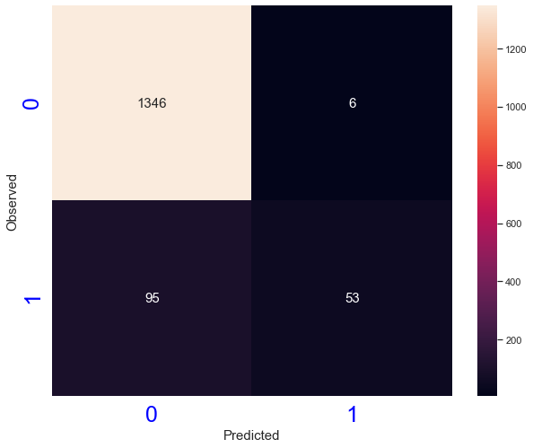

```python
# confusion matrix

cm_1= confusion_matrix(y_test,y_predict_1)
plt.figure(figsize=(10,8))
sns.heatmap(cm_1, annot=True, fmt='.0f', annot_kws={"size":15})
plt.ylabel('Observed', size=15)
plt.xlabel('Predicted', size=15);
plt.xticks(size=25, color='blue');
plt.yticks(size=25, color='blue');
```

```python
print("Recall:",recall_score(y_test,y_predict_1))
print()
print("Precision:",precision_score(y_test,y_predict_1))
print()
print("F1 Score:",f1_score(y_test,y_predict_1))
print()
print("Roc Auc Score:",roc_auc_score(y_test,y_predict_1))
```

```
Recall: 0.3581081081081081

Precision: 0.8983050847457628

F1 Score: 0.5120772946859904

Roc Auc Score: 0.6768351191428115
```

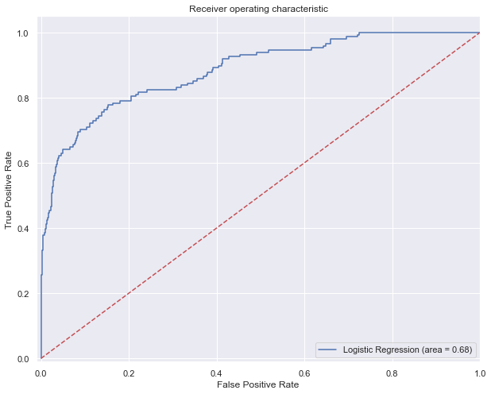

```python
#AUC ROC curve

logit_roc_auc = roc_auc_score(y_test, logreg1.predict(X_test_1))
fpr, tpr, thresholds = roc_curve(y_test, logreg1.predict_proba(X_test_1)[:,1],pos_label=1)
plt.figure(figsize=(10,8))
plt.plot(fpr, tpr, label='Logistic Regression (area = %0.2f)' % logit_roc_auc)
plt.plot([0, 1], [0, 1],'r--')
plt.xlim([-0.01, 1.0])
plt.ylim([-0.01, 1.05])
plt.xlabel('False Positive Rate')
plt.ylabel('True Positive Rate')
plt.title('Receiver operating characteristic')
plt.legend(loc="lower right")
plt.show()
```

```python
# get the best threshold
J = tpr - fpr
ix = np.argmax(J)
best_thresh = thresholds[ix]
print('Best Threshold=%f' % (best_thresh))
```

```
Best Threshold=0.109511
```

```
Logistic: f1=0.512 auc=0.652
```

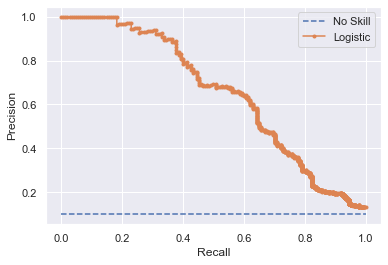

```python
# Precision Recall Curve

# calculate precision and recall for each threshold
lr_precision, lr_recall, threshold = precision_recall_curve(y_test, logreg1.predict_proba(X_test_1)[:,1], pos_label=1)
# calculate scores
lr_f1, lr_auc = f1_score(y_test,y_predict_1, pos_label=1), auc(lr_recall, lr_precision)
# summarize scores
print('Logistic: f1=%.3f auc=%.3f' % (lr_f1, lr_auc))
# plot the precision-recall curves
no_skill = len(y_test[y_test==1]) / len(y_test)
plt.plot([0, 1], [no_skill, no_skill], linestyle='--', label='No Skill')
plt.plot(lr_recall, lr_precision, marker='.', label='Logistic')
# axis labels
plt.xlabel('Recall')
plt.ylabel('Precision')
# show the legend
plt.legend()
# show the plot
plt.show()
```

```python
# convert to f score
fscore = (2 * lr_precision * lr_recall) / (lr_precision + lr_recall)
# locate the index of the largest f score
ix = np.argmax(fscore)
print('Best Threshold=%f, F-Score=%.3f' % (threshold[ix], fscore[ix]))
```

```
Best Threshold=0.244831, F-Score=0.625
```

```python
# Use the concept of threhold as below
threshold = 0.244831
y_predict_t1 = np.where(logreg1.predict_proba(X_test_1)[:,1]>threshold,1,0)
```

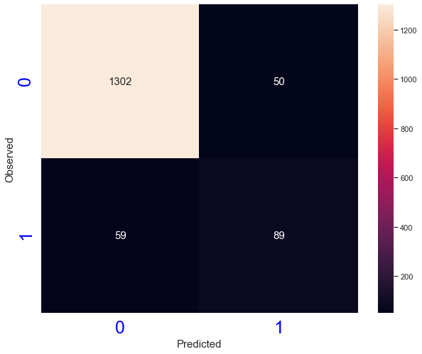

```python
# confusion matrix

cm_t1= confusion_matrix(y_test,y_predict_t1)
plt.figure(figsize=(10,8))
sns.heatmap(cm_t1, annot=True, fmt='.0f', annot_kws={"size":15})
plt.ylabel('Observed', size=15)
plt.xlabel('Predicted', size=15);
plt.xticks(size=25, color='blue');
plt.yticks(size=25, color='blue');
```

```python
print("Recall:",recall_score(y_test,y_predict_t1))
print()
print("Precision:",precision_score(y_test,y_predict_t1))
print()
print("F1 Score:",f1_score(y_test,y_predict_t1))
print()
print("Roc Auc Score:",roc_auc_score(y_test,y_predict_t1))
```

```
Recall: 0.6013513513513513

Precision: 0.6402877697841727

F1 Score: 0.6202090592334495

Roc Auc Score: 0.7821845514153206
```

**Observation:**

- Dropping income did not help improving the model prediction hence income should be considered in model </font>

## Final words:

Our original model including income as independent valiable works better by adjusting the following thresold based on stakeholders decission.

1. threshold = 0.142088: If identifying the possible customers is more important than some wrong customers are getting targetted for personal loan campaign
2. threshold = 0.293276: If we need to keep a balance between wrong customers being campained and right customers are not missed out.